# Assignment 5 - Import/Export Data, Here, and Factors

Mike Marin

# Introduction

This document is for Assignment #5. The goal of this assignment is to import/export data and make use of the *here* package, to improve the quality of plots, and to take *control* of *factors*.

# Exercise 1 - here::here , class is now in session!

Here, we will discuss the value of the **here** package.

**Before Reading the Blog:** The value of this package is in specifying the path to a file, when collaborating with others. It doesn’t seem to add a ton of value when working completely on your own, but can can make your script a bit more user friendly when passing scripts along to others as may be using a different OS or may organize files/directories in a diffrernt way. I’ve always began a script with a **where <- path.to.things** and then used this in what follows…allowing myself/others to change the *where* in the **setwd( where )**. But, I’m going to read this blog, and see the authors view on the value it adds.

**From Reading the Blog:** It suggests to use **Rprojects** and the **here()** command. The Rproject creates a working directory where the project is…you can also set R up to clean up the workspace for a new project. The value in **here()** is that it makes your script platform independent (for all those Windows users…bless their souls). It puts a *.here* extension on Rproject files, so that R knows where to look for them, and can find them regardless of where they are saved.

It is worth noting that this is very similar to the **file.path()** command in base R.

A nice thing about *here* is that if you move a file, this wont cause a problem with here…it will still find it without specifying a new path.

If you’ve set a working directory, *here()* will still be the priority, and wont be thrown off by the *setwd()*. And you can use *set_here()* if you wanted to set the “working directory” for here().

Overall, it just makes things a bit safer and user-friendly. The biggest benefit is with collaborative work. When working only yourself, it still adds a benefit that if files/directories get shifted around, your code will still run without having to tell R the new path to a file. This does add a benefit, as we do tend to clean up our work, move some work to “archived” folders, etc.

# Exercise 2 - Factor Management

For this exercise, we will use the *gapminder* dataset. Yes, this is an unoriginal choice, but I find this data interesting, and I’m also pretty familiar with it by now and don’t have to spend time getting familiar with data, and can focus on the technical content of the course.

First, let’s confirm that both *continent* and *country* are both factors, as we will be working with both of these.

```r
class(gapminder$continent)
```

```
## [1] "factor"
```

```r
class(gapminder$country)
```

```
## [1] "factor"
```

```r
# or, to get really specific...
is.factor(gapminder$continent)
```

```
## [1] TRUE
```

```r
is.factor(gapminder$country)
```

```
## [1] TRUE
```

And before we get to dropping Oceania, note the total number of rows in the data.

```r
nrow(gapminder)
```

```
## [1] 1704
```

## Drop Oceania…

First, let’s create a new dataframe (excuse me, a tibble…), with Oceania removed…

```r
NewGap <- gapminder %>%
  filter(continent != "Oceania")
nrow(NewGap)
```

```
## [1] 1680
```

We can see that there are 1680 rows in the data after removing Oceania…. there have been 24 rows dropped.

We now have data with **Oceania** removed, BUT…we can notice that the variable *continent* still has Oceania as one of the levels:

```r
levels(NewGap$continent)
```

```
## [1] "Africa"   "Americas" "Asia"     "Europe"   "Oceania"
```

```r
nlevels(NewGap$continent)
```

```
## [1] 5
```

So, let’s go ahead and have that level dropped. And I will create **NewGap** *again*. I will note that this is not necessary (we could just pipe in the NewGap and then droplevels()), but I’m doing this as it really should have all been done in one step, and I did this in small increments to demonstrate (mostly for myself) how removing Oceania from the data didn’t remove it as a level from the continent variable…

```r
NewGap <- gapminder %>%
  filter(continent != "Oceania") %>%
  droplevels()
```

Now, if we check the levels for continent (within the NewGap data), we will see that the level has been dropped…

```r
levels(NewGap$continent)
```

```
## [1] "Africa"   "Americas" "Asia"     "Europe"
```

```r
nlevels(NewGap$continent)
```

```
## [1] 4
```

## Re-order Levels of some Factor(s)

The question here reads as: “Reorder the levels of country or continent. Use the forcats package to change the order of the factor levels, based on summarized information of one of the quantitative variables. Consider experimenting with a summary statistic beyond the most basic choice of the mean/median. Use the forcats package in the tidyverse for this, rather than the baseR function as.factor.”

When doing this, I may create *New* variables that are reordered versions of the factors, when it makes sense to do so. I know that this is not necessary to do, but I want to be able to easily make side-by-side plots comparing the original version vs the reordered version of the factors, and this will make it easier for doing do (although not necessary).

Let’s __reorder continent by population in 2007_ and then look at a plot of the total population per continent. To do this, we will first have to *group_by()* continent and calculate the sum of population for each continent there. We will then make a plot of this. For this task, I will bring Oceania back as they deserve to be in there mate!

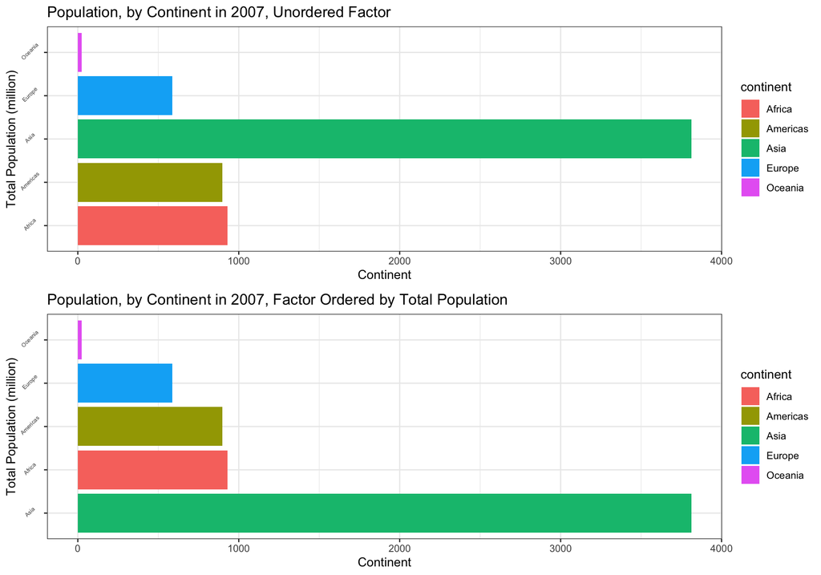

```r
Gap2 <- gapminder %>%
  filter(year==2007) %>%
  group_by(continent) %>%
  summarize(TotalPop = sum(pop, na.rm=T)/1000000)

plot1 <- Gap2 %>%
  ggplot() +
  geom_col(aes(x=continent, y=TotalPop, fill=continent)) +
  coord_flip()+
  theme_bw() +
  ggtitle("Population, by Continent in 2007, Unordered Factor") +
  ylab("Continent") +
  xlab("Total Population (million)") +
  coord_flip() +
  theme_bw() +
  theme(axis.text.y = element_text(angle = 45, vjust = 0,
                                   hjust=0.5, size=5))

plot2 <- Gap2 %>%
  ggplot() +
  geom_col(aes(x=fct_reorder(continent, -TotalPop), y=TotalPop, fill=continent)) +
  coord_flip()+
  theme_bw() +
  ggtitle("Population, by Continent in 2007, Factor Ordered by Total Population") +
  ylab("Continent") +
  xlab("Total Population (million)") +
  coord_flip() +
  theme_bw() +
  theme(axis.text.y = element_text(angle = 45, vjust = 0,
                                   hjust=0.5, size=5))

gridExtra::grid.arrange(plot1, plot2, nrow=2)
```

Let’s also look at the results of **arrange** on the original factor as well as the reordered one.

First, let’s see the original factor.

```r
DT::datatable(Gap2)
```

|  | continent | TotalPop |
| --- | --- | --- |
| 1 | Africa | 929.539692 |
| 2 | Americas | 898.871184 |
| 3 | Asia | 3811.953827 |
| 4 | Europe | 586.098529 |
| 5 | Oceania | 24.549947 |

Now, let’s look at that factor arranged by **TotalPop**, from largest to smallest.

```r
Gap2 %>%
  arrange(-TotalPop) %>%
  DT::datatable()
```

|  | continent | TotalPop |
| --- | --- | --- |
| 1 | Asia | 3811.953827 |
| 2 | Africa | 929.539692 |
| 3 | Americas | 898.871184 |
| 4 | Europe | 586.098529 |
| 5 | Oceania | 24.549947 |

# Exercise 3 - File Input and Output

The question read as: Task: Experiment with at least one of:

- write_csv()/read_csv() (and/or TSV friends),
- saveRDS()/readRDS(),
- dput()/dget().

## Make Something New

First, I will make a small addition to the *gapminder* data. Then I will export that data, and re-import it.

```r
ModifiedGapminder <- gapminder %>%
  filter(year==2007) %>%
  arrange(country) %>%
  mutate(GDP100mill = round((gdpPercap*pop)/100000000, digits=3))

DT::datatable(ModifiedGapminder)
```

|  | country | continent | year | lifeExp | pop | gdpPercap | GDP100mill |
| --- | --- | --- | --- | --- | --- | --- | --- |
| 1 | Afghanistan | Asia | 2007 | 43.828 | 31889923 | 974.5803384 | 310.793 |
| 2 | Albania | Europe | 2007 | 76.423 | 3600523 | 5937.029526 | 213.764 |
| 3 | Algeria | Africa | 2007 | 72.301 | 33333216 | 6223.367465 | 2074.449 |
| 4 | Angola | Africa | 2007 | 42.731 | 12420476 | 4797.231267 | 595.839 |
| 5 | Argentina | Americas | 2007 | 75.32 | 40301927 | 12779.37964 | 5150.336 |
| 6 | Australia | Oceania | 2007 | 81.235 | 20434176 | 34435.36744 | 7036.584 |
| 7 | Austria | Europe | 2007 | 79.829 | 8199783 | 36126.4927 | 2962.294 |
| 8 | Bahrain | Asia | 2007 | 75.635 | 708573 | 29796.04834 | 211.127 |
| 9 | Bangladesh | Asia | 2007 | 64.062 | 150448339 | 1391.253792 | 2093.118 |
| 10 | Belgium | Europe | 2007 | 79.441 | 10392226 | 33692.60508 | 3501.412 |

[output cut: 132 more lines]

## Export The Data

Now, we will export this data using *here::here()*.

```r
write_csv(ModifiedGapminder,
          here::here("ModifiedGapminder.csv"))
```

I’ve checked and the data was successfully exported.

## Re-Import The Data

Now, we will reimport the same data, except we will give it a new name, so that we can confirm that it made it back in one piece.

```r
ModifiedGapminderAgain <-
  read_csv(here::here("ModifiedGapminder.csv"))

DT::datatable(ModifiedGapminderAgain)
```

|  | country | continent | year | lifeExp | pop | gdpPercap | GDP100mill |
| --- | --- | --- | --- | --- | --- | --- | --- |
| 1 | Afghanistan | Asia | 2007 | 43.828 | 31889923 | 974.5803384 | 310.793 |
| 2 | Albania | Europe | 2007 | 76.423 | 3600523 | 5937.029526 | 213.764 |
| 3 | Algeria | Africa | 2007 | 72.301 | 33333216 | 6223.367465 | 2074.449 |
| 4 | Angola | Africa | 2007 | 42.731 | 12420476 | 4797.231267 | 595.839 |
| 5 | Argentina | Americas | 2007 | 75.32 | 40301927 | 12779.37964 | 5150.336 |
| 6 | Australia | Oceania | 2007 | 81.235 | 20434176 | 34435.36744 | 7036.584 |
| 7 | Austria | Europe | 2007 | 79.829 | 8199783 | 36126.4927 | 2962.294 |
| 8 | Bahrain | Asia | 2007 | 75.635 | 708573 | 29796.04834 | 211.127 |
| 9 | Bangladesh | Asia | 2007 | 64.062 | 150448339 | 1391.253792 | 2093.118 |
| 10 | Belgium | Europe | 2007 | 79.441 | 10392226 | 33692.60508 | 3501.412 |

[output cut: 132 more lines]

Looks like the data made it back in successfully.

## Play Around With Some Factors

I will order the country factors by the minimum *GDP*, and then make a plot of this.

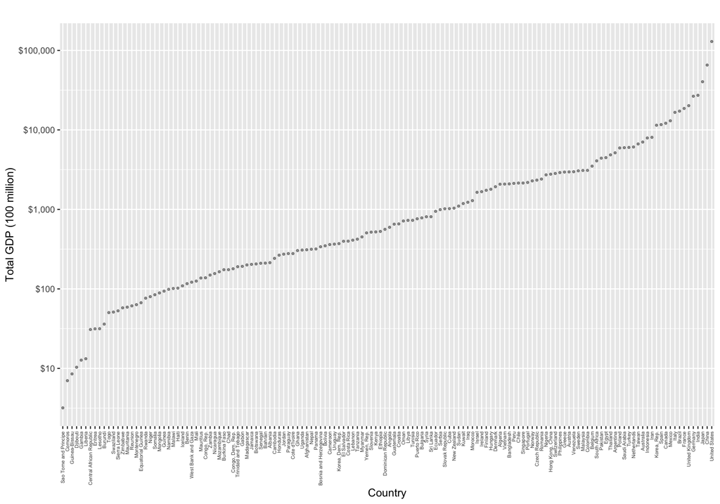

```r
ModifiedGapminderAgain %>%
  ggplot( aes(x=fct_reorder(country, GDP100mill, min),
              y=GDP100mill)) +
  geom_point(alpha=0.4, size=0.8) +
  scale_y_log10(labels=scales::dollar_format()) +
  ggtitle("") +
  ylab("Total GDP (100 million)") +
  xlab("Country") +
  theme(axis.text.x = element_text(angle = 90, vjust = 0.5,
                                   hjust=1, size=5))
```

The above plot is a bit messy, let’s try making the same plot, but this time with bars extended…

See that below.

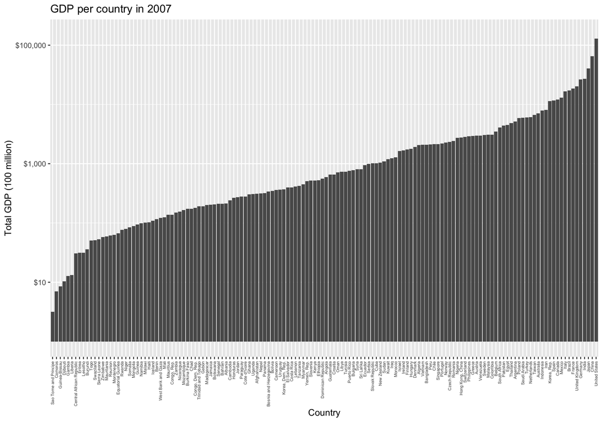

```r
ModifiedGapminderAgain %>%
  ggplot() +
  geom_col(aes(x=fct_reorder(country, GDP100mill, min),
               y=GDP100mill)) +
  scale_y_log10(labels=scales::dollar_format(),
                limits=c(1,150000)) +
  ggtitle("GDP per country in 2007") +
  ylab("Total GDP (100 million)") +
  xlab("Country") +
  theme(axis.text.x = element_text(angle = 90, vjust = 0.5,
                                   hjust=1, size=5))
```

This plot also has a bit too much going on, and isn’t easily readable. It would need to be more interactive to be of any value. I believe that *Shiny* and/or *Plotly* are ways that we could do that, and I’m hoping this is something that gets covered in decent detail in the next course.

# Exercise 4 - Visualization Design

For this exercise, we will take a plot produced previously, and then jazz it up using some of the new thigns we’ve learned.

It iw worth mentioning that learning about *ggplot2* was one of my main goals for the course, so when producing plots, I tended to go above an beyond what was required, so some of the previously produced plots may already look decent…but I’m sure i can add at least one nice new feature to them.

## Class 8 Exercise Revision

The first plot I will modify is a plot produced in the in-class exercises from lecture 08. I will place the old and new version on top of each other. Because of the dimensions of the plot, I believe this is a more effective visual comparison than placing them side-by-side.

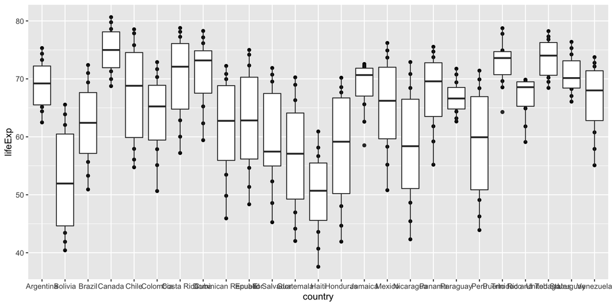

```r
gapminder %>%
  filter(continent == "Americas") %>%
  ggplot(aes(country, lifeExp)) +
  geom_point() +
  geom_boxplot()
```

We can see that the plot isn’t very nice looking. The axes could have cleaner labels. The plot lacks a title. The country names are not readable. The boxplots/countries could be ordered by median life expectancy,…

Let’s make some of those changes…

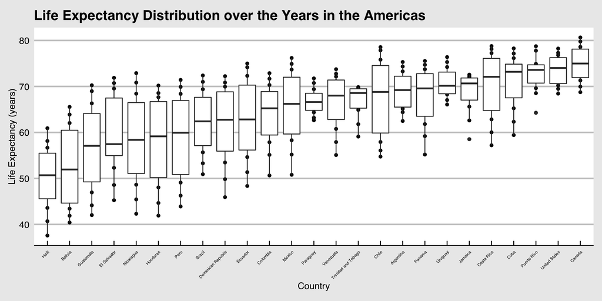

```r
gapminder %>%
  filter(continent == "Americas") %>%
  ggplot(aes(fct_reorder(country, lifeExp, median), lifeExp)) +
  geom_point() +
  geom_boxplot() +
  ggtitle("Life Expectancy Distribution over the Years in the Americas") +
  xlab("Country") +
  ylab("Life Expectancy (years)") +
  ggthemes::theme_economist_white() +
  theme(axis.text.x = element_text(angle = 45, vjust = 1,
                                   hjust=1, size=5))
```

## Assignment 2 Plot Revision

As an other exercise, I will take a plot I produced for Assignment #2 and make it look a bit nicer. It is a simple barchart, but I will make it look a bit nicer. First, the original version:

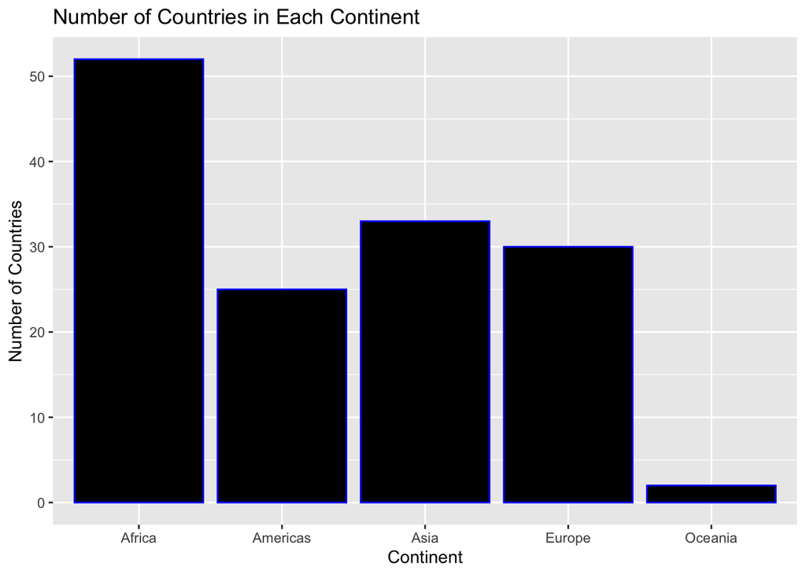

```r
gapminder %>%
  filter(year == 2007) %>%
  select(continent) %>%
  ggplot() +
  aes(continent) +
  geom_bar( col="blue", fill="black") +
  ggtitle("Number of Countries in Each Continent") +
  xlab("Continent") +
  ylab("Number of Countries")
```

And now, a slightly nicer looking version:

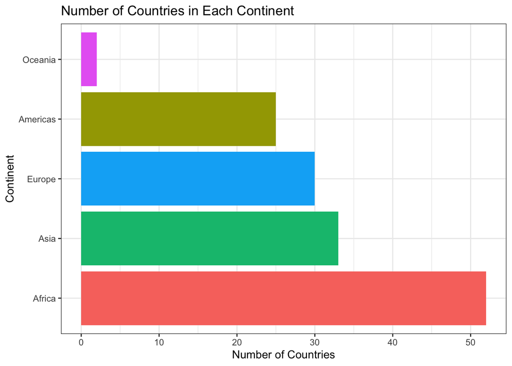

```r
gapminder %>%
  filter(year == 2007) %>%
  select(continent) %>%
  ggplot() +
  aes(fct_infreq(continent), fill=continent) +
  coord_flip() +
  geom_bar() +
  ggtitle("Number of Countries in Each Continent") +
  xlab("Continent") +
  ylab("Number of Countries") +
  theme_bw() +
  theme(legend.position="none")
```

You can see that the second is much nicer. It is easier to compare size of countries having the bars ordered in increasing size. It also is a bit easier to compare having the bars being different colours…and since each bar is a different continent, it isn’t overkill having each bar a different colour (it may be too much colour if they are just different levels for a categorical variable, but since they represent different continents, it is definitely helpful to visually separate them this way)

Now, suppose we wanted to highlight *Asia* on the plot, we could use a different colour for them to draw visual attention to them….see below:

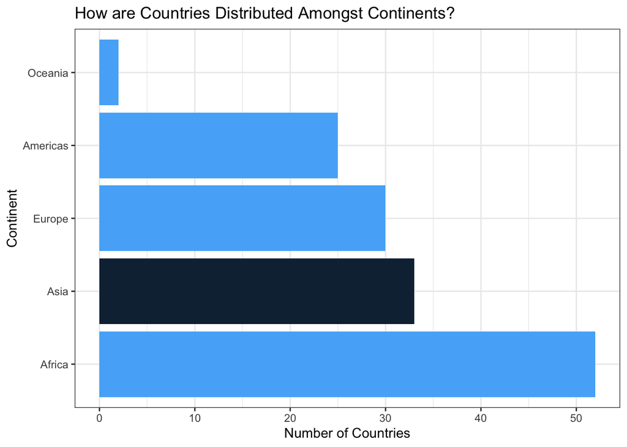

```r
gapminder %>%
  filter(year == 2007) %>%
  select(continent) %>%
  ggplot() +
  aes(fct_infreq(continent), fill=as.numeric(continent!="Asia")) +
  coord_flip() +
  geom_bar() +
  ggtitle("How are Countries Distributed Amongst Continents?") +
  xlab("Continent") +
  ylab("Number of Countries") +
  theme_bw() +
  theme(legend.position="none")
```

Note that the *as.numeric()* isn’t necessary, and just gets us a different set of colours…but I prefer the look of different shades of blue, as it draws attention to Asia while still having the same shade of colours.

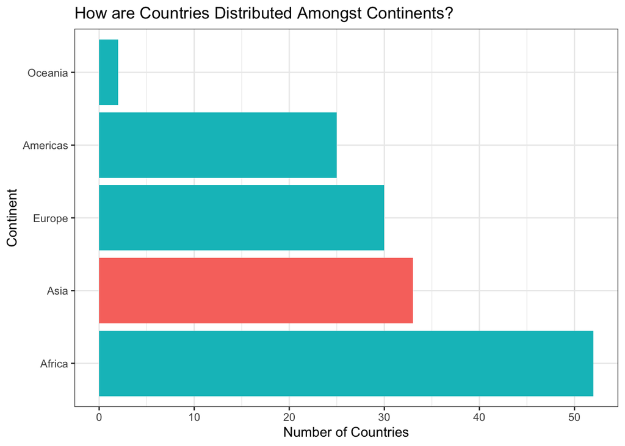

```r
gapminder %>%
  filter(year == 2007) %>%
  select(continent) %>%
  ggplot() +
  aes(fct_infreq(continent), fill=(continent!="Asia")) +
  coord_flip() +
  geom_bar() +
  ggtitle("How are Countries Distributed Amongst Continents?") +
  xlab("Continent") +
  ylab("Number of Countries") +
  theme_bw() +
  theme(legend.position="none")
```

# Exercise 5 - Write Figure to File

The exercise reads as follows:

Task: Use ggsave() to explicitly save a plot to file. Include the exported plot as part of your repository and assignment.

Then, use **[Alt text] /path/to/img.png** to load and embed that file into your report. You can play around with various options, such as:

- Arguments of ggsave(), such as width, height, resolution or text scaling.
- Various graphics devices, e.g. a vector vs. raster format.
- Explicit provision of the plot object p via ggsave(…, plot = p). Show a situation in which this actually matters.

## Make a Plot to Save

Here I will reproduce one of the earlier plots, and save it in an object called **pLoTnAmE**. I will then save this plot to file. I will intentionally *not* show the plot here.

```r
pLoTnAmE <- gapminder %>%
  filter(continent == "Americas") %>%
  ggplot(aes(fct_reorder(country, lifeExp, median), lifeExp)) +
  geom_point() +
  geom_boxplot() +
  ggtitle("The Plot I Saved and Exported to File") +
  xlab("Country") +
  ylab("Life Expectancy (years)") +
  ggthemes::theme_economist_white() +
  theme(axis.text.x = element_text(angle = 45, vjust = 1,
                                   hjust=1, size=5))
```

## Save Plot using ggsave()

Now, I will save the plot created above.

```r
ggsave(here::here("PlotToSave.png"), plot=pLoTnAmE)
```

Now, I will load in that plot, and embed it in right here…

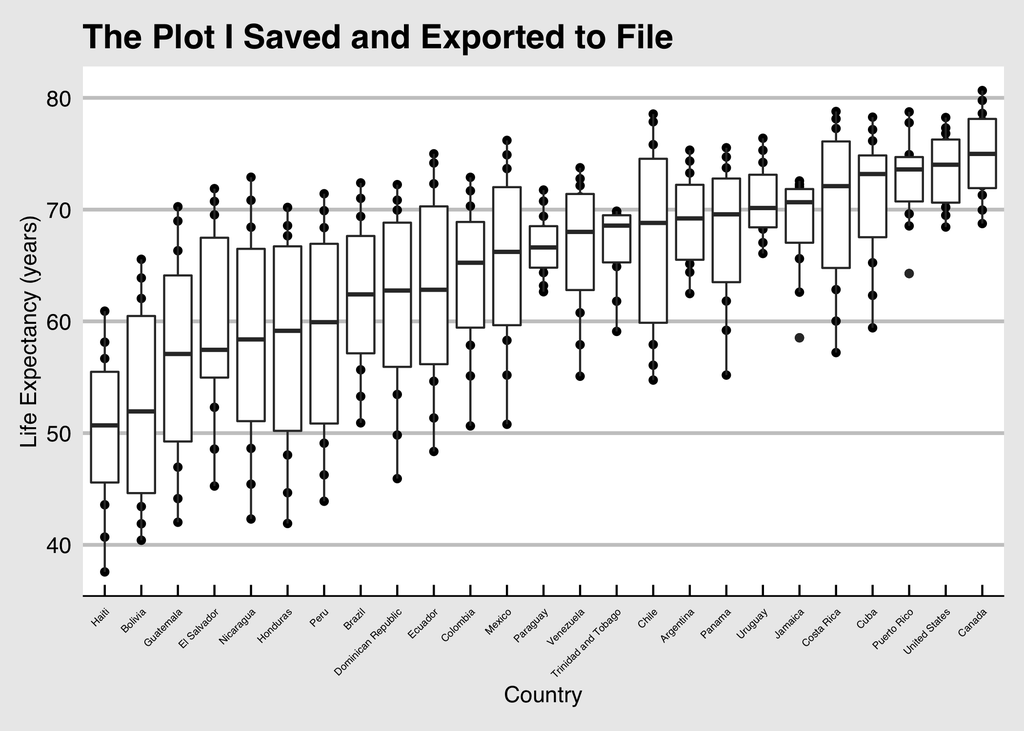

Figure X: The Imported Plot

This plot looks right.

One of the values of using **plot=PlotName** is that it allows you to save any plot. If you do not specify the plot name, then R will save the most recently created plot.

## Play Around with Settings

Now below, I will play around with some of the height, width, resoultion, etc. I will note here that I’ve had some challenges with this! What I thought were reasonable values resulted in really large or really timy plots, things all out of proportion, etc. It has taken a long time to get a plot that didn’t look ridiculous!

Let’s see what I mean, take a look at the below….seems reasonable, right?

```r
ggsave(here::here("PlotToSaveAgain.png"), plot = pLoTnAmE,
       width = 60, height = 40, units = "mm")
```

Well, look at it once its embedded!!

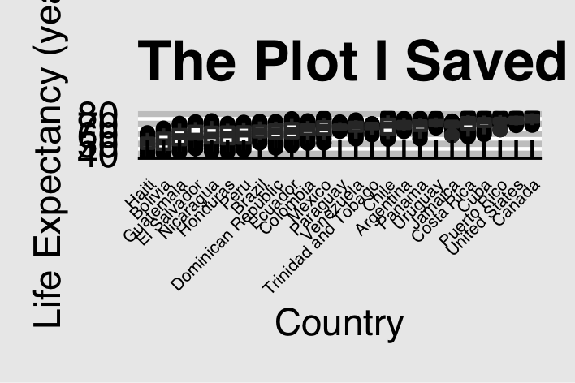

Figure XX: Ridiculous Imported Plot

Now that’s a sorry looking plot!! Once guess I have is that it may be related to the fact that when I produced the plot originally, I set figure width/height, so maybe the values im setting in the *ggsave( )* aren’t exactly what I think they are.

Let’s try making the plot again, but this time not setting a width/height in the initial production of the plot, and then see what these same values result in.

Make that exact same plot, but remove the height/width, and give it a slightly different name.

```r
pLoTnAmE2 <- gapminder %>%
  filter(continent == "Americas") %>%
  ggplot(aes(fct_reorder(country, lifeExp, median), lifeExp)) +
  geom_point() +
  geom_boxplot() +
  ggtitle("The Plot I Saved and Exported to File") +
  xlab("Country") +
  ylab("Life Expectancy (years)") +
  ggthemes::theme_economist_white() +
  theme(axis.text.x = element_text(angle = 45, vjust = 1,
                                   hjust=1, size=5))
```

Now, save it with a new name. I’m also removing the units…

```r
ggsave(here::here("PlotToSaveAgainAgain.png"), plot = pLoTnAmE2,
       width = 5, height = 3)
```

And let’s see what it looks like once it’s embedded.

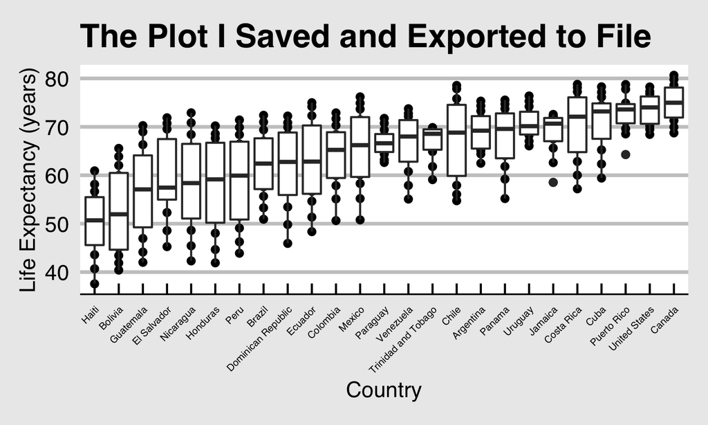

Figure XXX: Another Imported Plot

Well, I need to work a bit more on setting values for plots that are not the default and getting them to look good. For now, I will leave things here as I don’t have the time to explore this further at the moment…

But wait, one more minute…aha, i figured out a large part of the problem! When embedding, it seems to scale the plot to full page width, so if the plot is too small, it gets all stretched an out of proportion! I will play around a bit more with this later, but I’ve made some sense of if for now… at least I know *why* its all out of poropotion, now I just need to figure out *how* to not have it do that (possibly have to specify the height/width in the embed code)!